# Mixed-Effects Analysis of Energy Score Trajectories in T2D & SIHD Patients

Hajin Jang

9/14/2025

### This analysis evaluates longitudinal changes in energy scores across 2×2 randomized treatment strategies in patients with type 2 diabetes and stable ischemic heart disease, using mixed-effects models to account for within-subject correlation from repeated measurements.

## About the data

This study uses data from a 2×2 factorial randomized clinical trial of adults with type 2 diabetes mellitus and stable ischemic heart disease, in which participants were assigned to different cardiac and glycemic treatment strategies and followed for up to four years. The objective is to examine whether energy scores change over time and differ by treatment assignment, while appropriately accounting for the correlation among repeated measurements within individuals using longitudinal mixed-effects models.

## Data Import

```r
library(readr)
library(tableone)
library(dplyr)
library(gt)
library(mice)

dmihd <- read_csv("dmihd.csv")
str(dmihd)
```

```
spc_tbl_ [9,748 × 15] (S3: spec_tbl_df/tbl_df/tbl/data.frame)
 $ id          : num [1:9748] 1101 1101 1101 1101 1101 ...
 $ year        : num [1:9748] 0 1 2 3 4 0 1 2 1 2 ...
 $ cardtrt     : num [1:9748] 1 1 1 1 1 0 0 0 0 0 ...
 $ diabtrt     : num [1:9748] 0 0 0 0 0 0 0 0 1 1 ...
 $ trt         : num [1:9748] 3 3 3 3 3 1 1 1 2 2 ...
 $ age         : num [1:9748] 47 47 47 47 47 71 71 71 73 73 ...
 $ age4        : num [1:9748] 1 1 1 1 1 4 4 4 4 4 ...
 $ sex         : num [1:9748] 1 1 1 1 1 1 1 1 1 1 ...
 $ raceeth     : num [1:9748] 2 2 2 2 2 1 1 1 1 1 ...
 $ bmi         : num [1:9748] 36 36 36 36 36 ...
 $ bmi4        : num [1:9748] 3 3 3 3 3 1 1 1 2 2 ...
 $ energy      : num [1:9748] 65 25 60 50 55 35 35 35 70 45 ...
 $ energy0     : num [1:9748] 65 65 65 65 65 35 35 35 45 45 ...
 $ energychange: num [1:9748] 0 -40 -5 -15 -10 0 0 0 25 0 ...
 $ death       : num [1:9748] 0 0 0 0 0 0 0 0 1 1 ...
 - attr(*, "spec")=
  .. cols(
  ..   id = col_double(),
  ..   year = col_double(),
  ..   cardtrt = col_double(),
  ..   diabtrt = col_double(),
  ..   trt = col_double(),
  ..   age = col_double(),
  ..   age4 = col_double(),
  ..   sex = col_double(),
  ..   raceeth = col_double(),
  ..   bmi = col_double(),
  ..   bmi4 = col_double(),
  ..   energy = col_double(),
  ..   energy0 = col_double(),
  ..   energychange = col_double(),
  ..   death = col_double()
  .. )
 - attr(*, "problems")=<externalptr>
```

```r
dmihd <- dmihd %>%
  mutate(sex = as.factor(sex),
         raceeth = as.factor(raceeth),
         cardtrt = as.factor(cardtrt),
         diabtrt = as.factor(diabtrt),
         trt = as.factor(trt),
         age4 = as.factor(age4),
         bmi4 = as.factor(bmi4),
         death = as.factor(death))
```

## Table 1

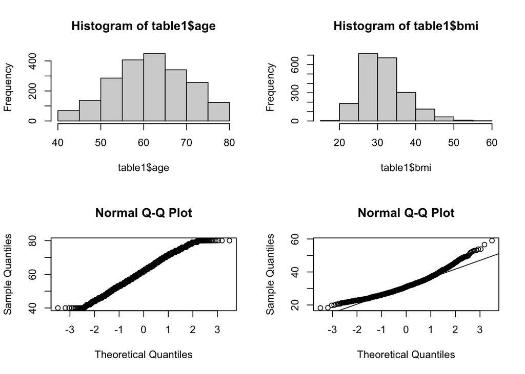

```r
table1 <- dmihd %>% filter(year == 0)

vars <- c("age", "sex", "raceeth", "bmi")
cat_vars <- c("sex", "raceeth")

# check for normality of continuous variables
par(mfrow = c(2, 2))
hist(table1$age)
hist(table1$bmi)
qqnorm(table1$age)
qqline(table1$age)
qqnorm(table1$bmi)
qqline(table1$bmi)
```

```r
# For All patient
table1_all <- CreateTableOne(vars = vars, data = table1, factorVars = cat_vars)
print(table1_all, showAllLevels = TRUE)
```

```
                  level Overall
  n                      2071
  age (mean (SD))       61.92 (8.76)
  sex (%)         1      1467 (70.8)
                  2       604 (29.2)
  raceeth (%)     1      1379 (66.6)
                  2       431 (20.8)
                  3       261 (12.6)
  bmi (mean (SD))       31.64 (5.71)
```

```r
# For cardtrt
table1_cardtrt <- CreateTableOne(vars = vars, strata = "cardtrt", data = table1, factorVars = cat_vars)
print(table1_cardtrt, showAllLevels = TRUE)
```

```
                 Stratified by cardtrt
                  level 0             1             p      test
  n                      1054          1017
  age (mean (SD))       62.04 (8.90)  61.80 (8.61)   0.536
  sex (%)         1       741 (70.3)    726 (71.4)   0.622
                  2       313 (29.7)    291 (28.6)
  raceeth (%)     1       712 (67.6)    667 (65.6)   0.630
                  2       212 (20.1)    219 (21.5)
                  3       130 (12.3)    131 (12.9)
  bmi (mean (SD))       31.89 (5.70)  31.39 (5.71)   0.047
```

```r
# For diabtrt
table1_diabtrt <- CreateTableOne(vars = vars, strata = "diabtrt", data = table1, factorVars = cat_vars)
print(table1_diabtrt, showAllLevels = TRUE)
```

```
                 Stratified by diabtrt
                  level 0             1             p      test
  n                      1052          1019
  age (mean (SD))       61.94 (9.03)  61.90 (8.46)   0.923
  sex (%)         1       742 (70.5)    725 (71.1)   0.795
                  2       310 (29.5)    294 (28.9)
  raceeth (%)     1       701 (66.6)    678 (66.5)   0.867
                  2       222 (21.1)    209 (20.5)
                  3       129 (12.3)    132 (13.0)
  bmi (mean (SD))       31.65 (5.68)  31.64 (5.74)   0.981
```

```r
# Combine them into a table1
data <- data.frame(
  Variable = c("Number of patients (n)", "Age (years, sd)", "Sex (female, %)", "Race/Ethnicity (%)","  Non-Hispanic white",  "  Non-Hispanic nonwhite", "  Hispanic", "BMI (kg/m2, sd)"),

  All_Patients = c(2071, "61.92 (8.76)", "604 (29.2)", " ", "1379 (66.6)", "431 (20.8)", "261 (12.6)", "31.64 (5.71)"),

  Revascularization = c(1017, "61.80 (8.61)", "291 (28.6)", " ", "667 (65.6)", "219 (21.5)", "131 (12.9)", "31.39 (5.71)"),
  Medical_Therapy = c(1054, "62.04 (8.90)", "313 (29.7)", " ", "712 (67.6)", "212 (20.1)", "130 (12.3)", "31.89 (5.70)"),
  P_Value_Card = c("", "0.536", "0.622", "0.630", "", "", "", "0.047"),

  Insulin_Sensitization = c(1052, "61.94 (9.03)", "310 (29.5)", " ", "701 (66.6)", "222 (21.1)", "129 (12.3)", "31.65 (5.68)"),
  Insulin_Provision = c(1019, "61.90 (8.46)", "294 (28.9)", " ", "678 (66.5)", "209 (20.5)", "132 (13.0)", "31.64 (5.74)"),
  P_Value_Diab = c("", "0.923", "0.795", "0.867", "", "", "", "0.981")
)

gt_table <- data %>%
  gt() %>%
  tab_header(
    title = "Baseline Characteristics by Treatment Strategy"
  ) %>%
  cols_label(
    Variable = "Variable",
    All_Patients = "All patients at baseline",
    Revascularization = "Early Coronary Revascularization",
    Medical_Therapy = "Medical Therapy",
    P_Value_Card = "P-value",
    Insulin_Sensitization = "Insulin Sensitization",
    Insulin_Provision = "Insulin Provision",
    P_Value_Diab = "P-value"
  ) %>%
  tab_footnote(
    footnote = "Continuous variables are represented as mean (SD), with P-values based on t-test.",
    locations = cells_body(columns = 1, rows = c(2,8))
  ) %>%
  tab_footnote(
    footnote = "Categorical variables are represented as N (%), with P-values based on chi-square test.",
    locations = cells_body(columns = 1, rows = c(3:7))
  )

gt_table
```

Baseline Characteristics by Treatment Strategy

| Variable | All patients at baseline | Early Coronary Revascularization | Medical Therapy | P-value | Insulin Sensitization | Insulin Provision | P-value |
| --- | --- | --- | --- | --- | --- | --- | --- |
| Number of patients (n) | 2071 | 1017 | 1054 |  | 1052 | 1019 |  |
| Age (years, sd)<sup>1</sup> | 61.92 (8.76) | 61.80 (8.61) | 62.04 (8.90) | 0.536 | 61.94 (9.03) | 61.90 (8.46) | 0.923 |
| Sex (female, %)<sup>2</sup> | 604 (29.2) | 291 (28.6) | 313 (29.7) | 0.622 | 310 (29.5) | 294 (28.9) | 0.795 |
| Race/Ethnicity (%)<sup>2</sup> |  |  |  | 0.630 |  |  | 0.867 |
| Non-Hispanic white<sup>2</sup> | 1379 (66.6) | 667 (65.6) | 712 (67.6) |  | 701 (66.6) | 678 (66.5) |  |
| Non-Hispanic nonwhite<sup>2</sup> | 431 (20.8) | 219 (21.5) | 212 (20.1) |  | 222 (21.1) | 209 (20.5) |  |
| Hispanic<sup>2</sup> | 261 (12.6) | 131 (12.9) | 130 (12.3) |  | 129 (12.3) | 132 (13.0) |  |
| BMI (kg/m2, sd)<sup>1</sup> | 31.64 (5.71) | 31.39 (5.71) | 31.89 (5.70) | 0.047 | 31.65 (5.68) | 31.64 (5.74) | 0.981 |

<sup>1</sup> Continuous variables are represented as mean (SD), with P-values based on t-test.  
<sup>2</sup> Categorical variables are represented as N (%), with P-values based on chi-square test.

**Justification:** T-tests or Wilcoxon tests were selected depending on the distribution of the continuous variables. Based on the histogram plots, both age and BMI showed slight skewness but were still reasonably close to a normal distribution, so t-tests were deemed appropriate. For categorical variables, Chi-square or Fisher’s exact tests were considered. Since all expected cell counts exceeded 5, the Chi-square test was used.

## EDA

#### For the whole dataset

```r
MP <- md.pattern(dmihd[, c("age", "sex", "raceeth", "bmi", "energy", "trt")])
```

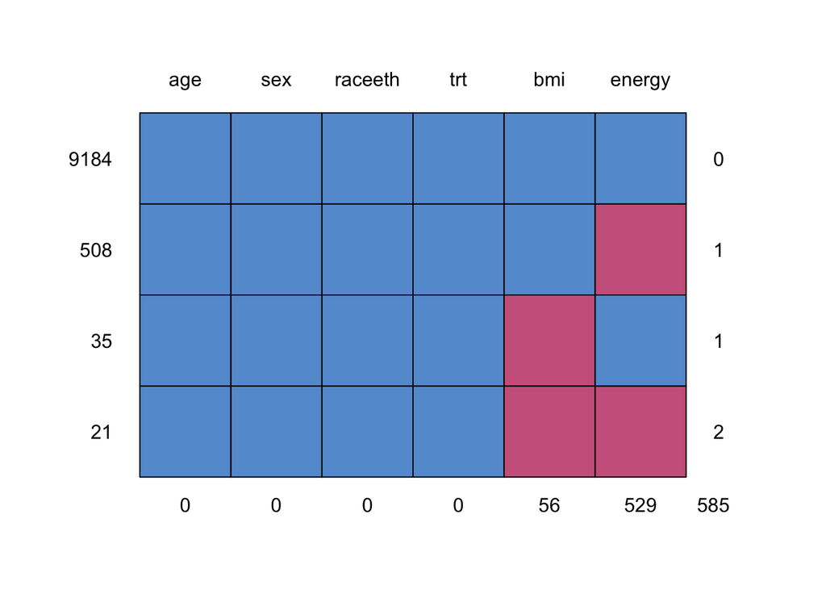

```r
MP_trt1 <- md.pattern(dmihd[ dmihd$trt == 1, c("age", "sex", "raceeth", "bmi", "energy")])
```

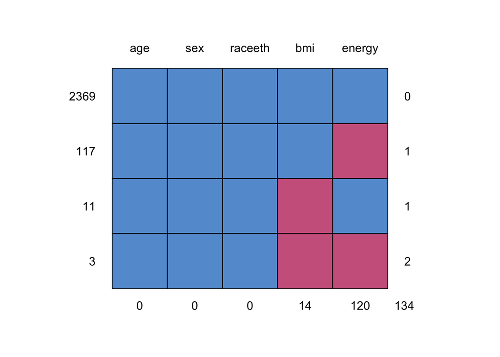

```r
MP_trt2 <- md.pattern(dmihd[ dmihd$trt == 2, c("age", "sex", "raceeth", "bmi", "energy")])
```

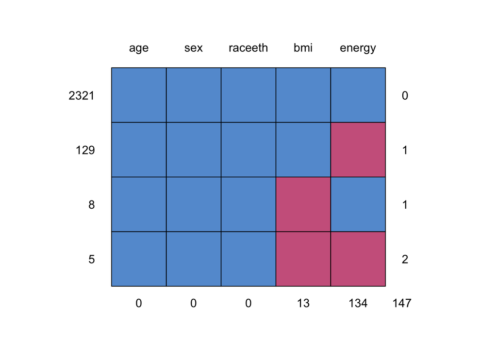

```r
MP_trt3 <- md.pattern(dmihd[ dmihd$trt == 3, c("age", "sex", "raceeth", "bmi", "energy")])
```

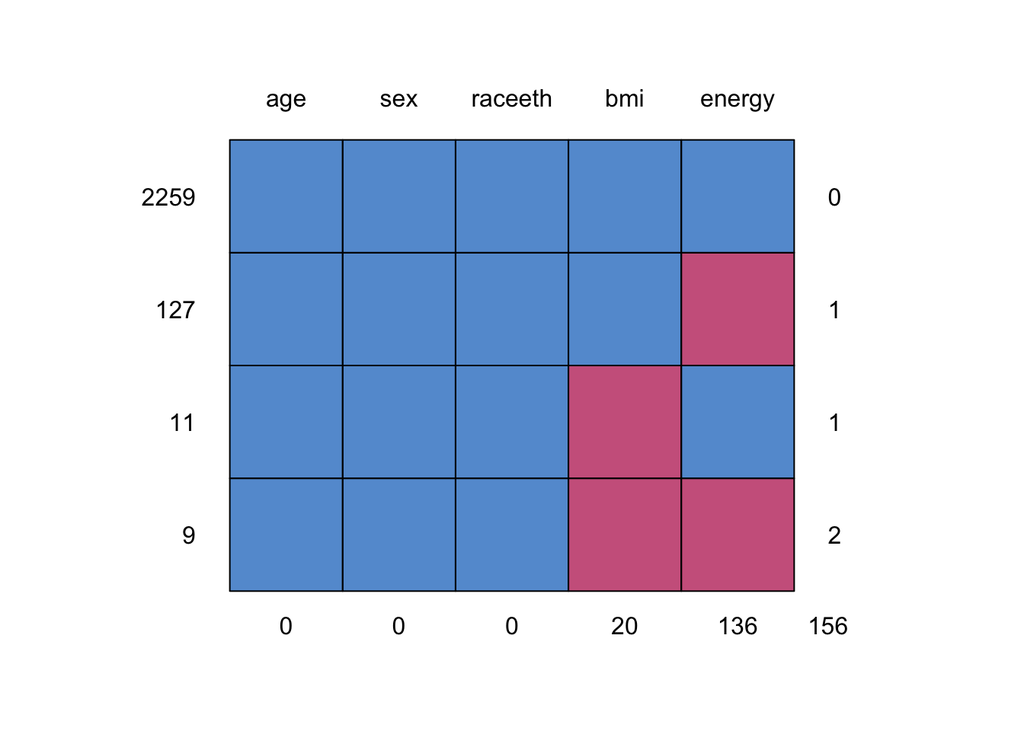

```r
MP_trt4 <- md.pattern(dmihd[ dmihd$trt == 4, c("age", "sex", "raceeth", "bmi", "energy")])
```

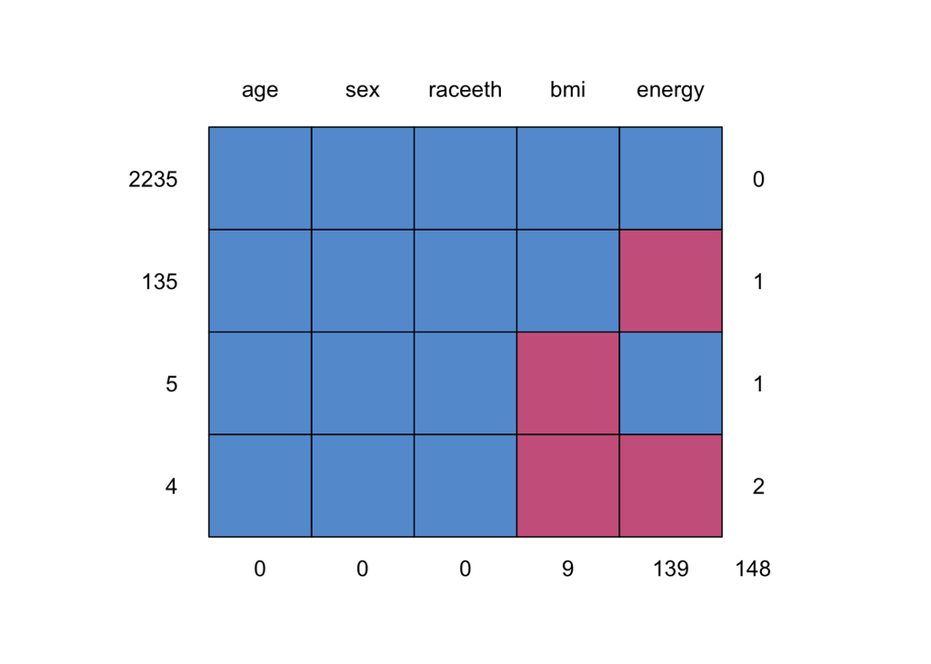

#### Only baseline

```r
Mp_base <- md.pattern(table1[, c("age", "sex", "raceeth", "bmi", "energy", "trt")])
```

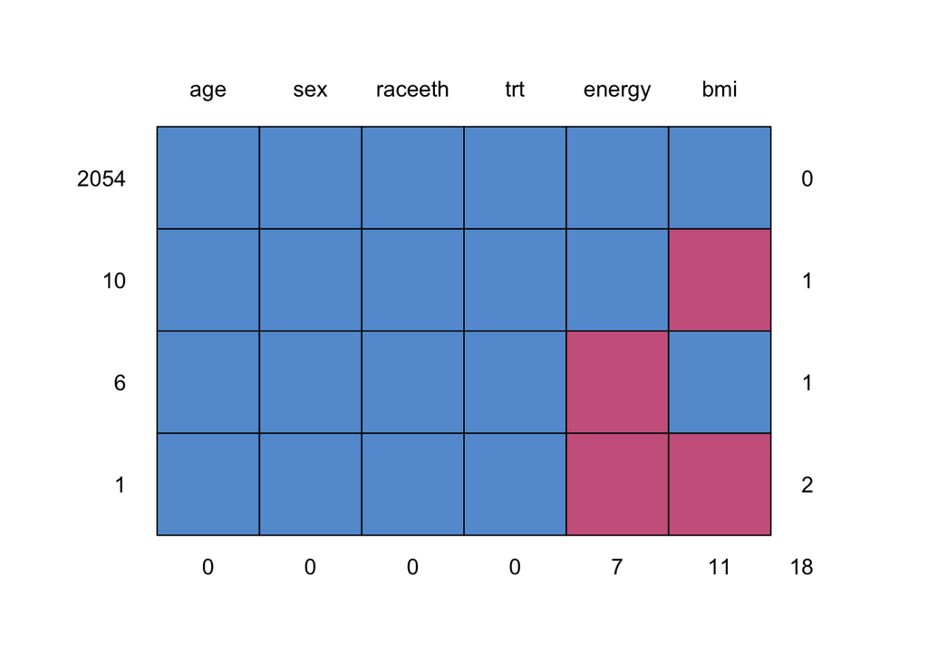

```r
MP_trt1_base <- md.pattern(table1[ table1$trt == 1, c("age", "sex", "raceeth", "bmi", "energy")])
```

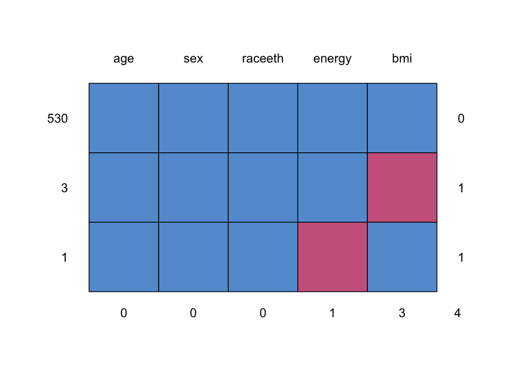

```r
MP_trt2_base <- md.pattern(table1[ table1$trt == 2, c("age", "sex", "raceeth", "bmi", "energy")])
```

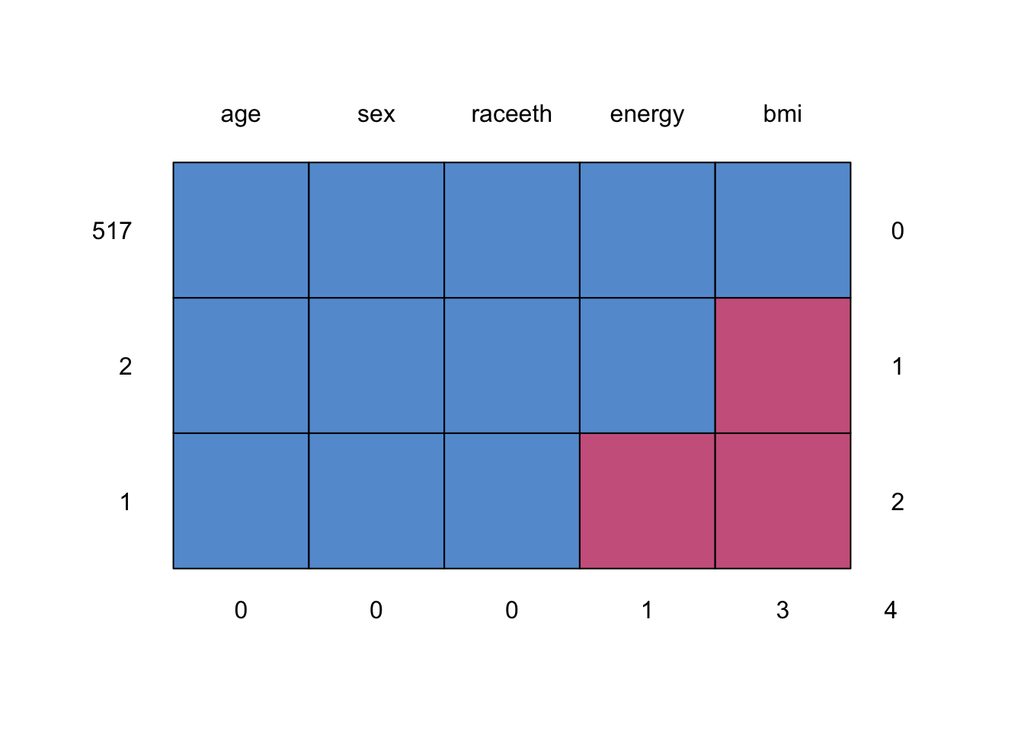

```r
MP_trt3_base <- md.pattern(table1[ table1$trt == 3, c("age", "sex", "raceeth", "bmi", "energy")])
```

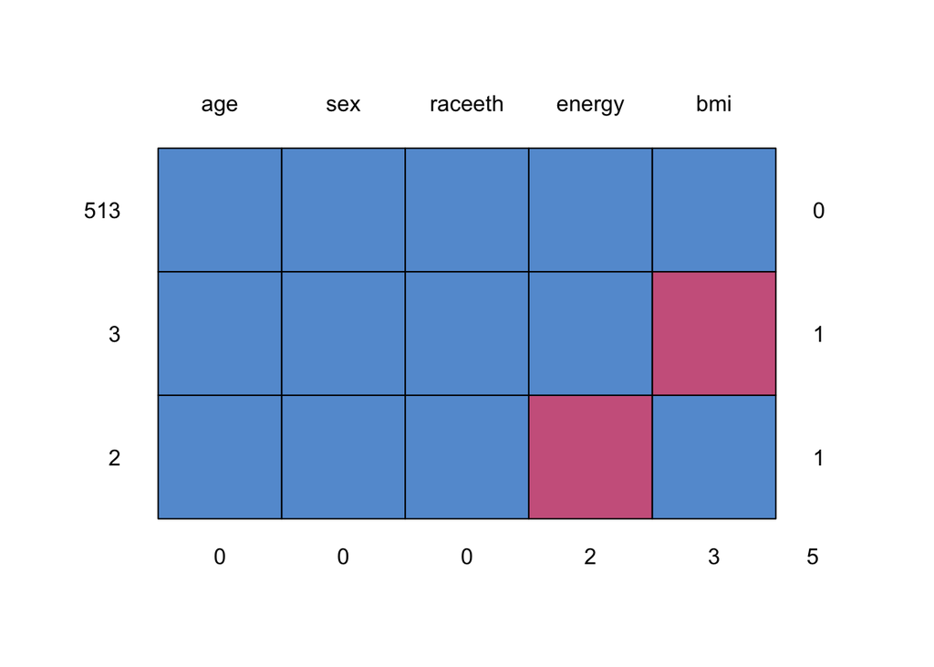

```r
MP_trt4_base <- md.pattern(table1[ table1$trt == 4, c("age", "sex", "raceeth", "bmi", "energy")])
```

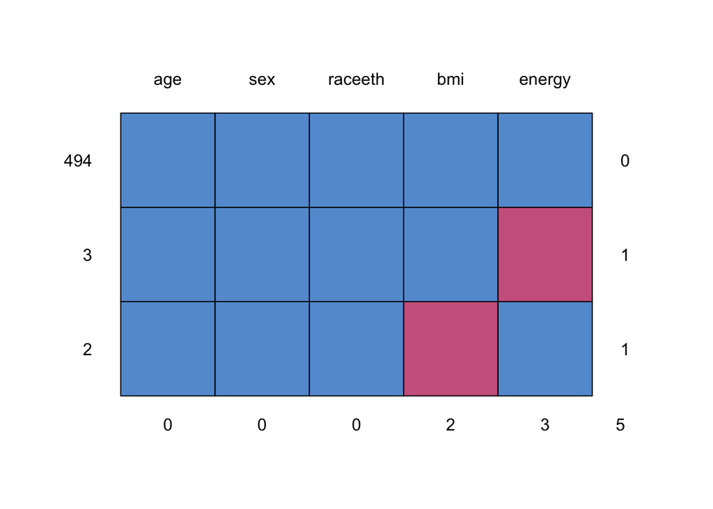

```r
# missing by treatment group (trt) for the whole dataset
NA_by_trt <- dmihd %>%
  group_by(trt) %>%
  summarise(
    total = n(),
    NA_energy = sum(is.na(energy)),
    NA_energy_pct = sum(is.na(energy))/total,
    NA_bmi = sum(is.na(bmi)),
    NA_bmi_pct = sum(is.na(bmi))/total
  ) %>%
  ungroup()

# display the missingness in energy by treatment group
print(NA_by_trt)
```

```
# A tibble: 4 × 6
  trt   total NA_energy NA_energy_pct NA_bmi NA_bmi_pct
  <fct> <int>     <int>         <dbl>  <int>      <dbl>
1 1      2500       120        0.048      14    0.0056
2 2      2463       134        0.0544     13    0.00528
3 3      2406       136        0.0565     20    0.00831
4 4      2379       139        0.0584      9    0.00378
```

```r
# missing by treatment group (trt) for only baseline
NA_by_trt_base <- table1 %>%
  group_by(trt) %>%
  summarise(
    total = n(),
    NA_energy = sum(is.na(energy)),
    NA_energy_pct = sum(is.na(energy))/total,
    NA_bmi = sum(is.na(bmi)),
    NA_bmi_pct = sum(is.na(bmi))/total
  ) %>%
  ungroup()

print(NA_by_trt_base)
```

```
# A tibble: 4 × 6
  trt   total NA_energy NA_energy_pct NA_bmi NA_bmi_pct
  <fct> <int>     <int>         <dbl>  <int>      <dbl>
1 1       534         1       0.00187      3    0.00562
2 2       520         1       0.00192      3    0.00577
3 3       518         2       0.00386      3    0.00579
4 4       499         3       0.00601      2    0.00401
```

**Missing Data Pattern:** The missing data pattern shows that only BMI and energy score have missing values. There are 9,184 complete observations, with 529 missing energy scores and 56 missing BMI values. Of these, 21 observations are missing both BMI and energy scores, 35 are missing only BMI, and 508 are missing only energy.

**Missing Pattern by Treatment Group:** The proportion of missing energy data is fairly consistent across all treatment groups, ranging from 4.80% to 5.84%, suggesting that missingness is not strongly associated with any specific group. Similarly, the missing BMI data is minimal and evenly distributed, with rates between 0.38% and 0.83% across groups.

**Conclusion:** Given the low and balanced levels of missingness across treatment groups, the missing data appears to be random or, at the very least, not related to treatment assignment.

## Association analysis

#### Plotting the average observed energy trajectories over time per treatment group.

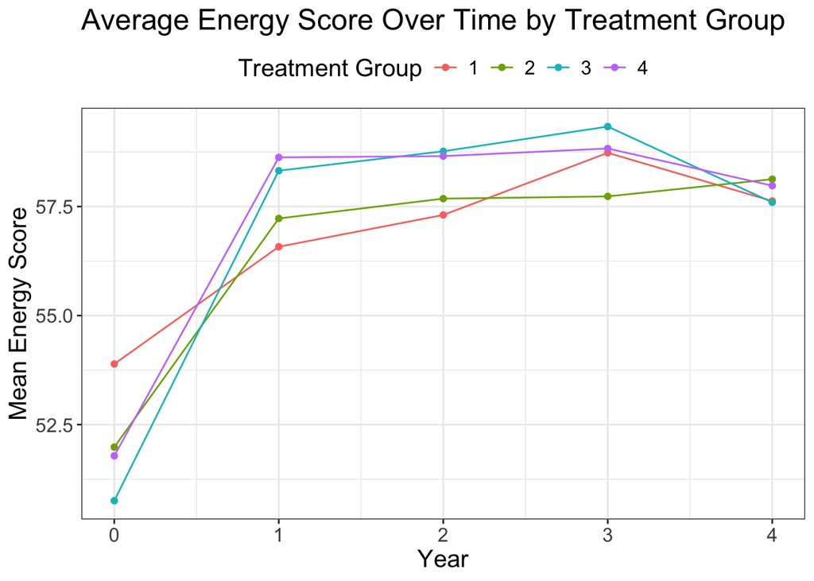

```r
library(ggplot2)
energy_summary <- dmihd %>%
  group_by(trt, year) %>%
  filter(!is.na(trt) & !is.na(year)) %>%
  summarise(mean_energy = mean(energy, na.rm = TRUE))

energy_plot <- ggplot(energy_summary, aes(x = year, y = mean_energy, group = trt, color = as.factor(trt))) +
  geom_point() +
  geom_line() +
  theme_bw() +
  theme(text = element_text(size = 15), legend.position = "top") +
  labs(x = "Year", y = "Mean Energy Score", color = "Treatment Group", title = "Average Energy Score Over Time by Treatment Group")

print(energy_plot)
```

**Comment:** At baseline, Group 1 had the highest average energy score, followed by Groups 2, 4, and 3, in that order. All treatment groups showed a notable increase in energy scores during the first year after treatment initiation. Beyond year 1, energy scores either remained stable or showed slight fluctuations: Group 1 continued to improve through year 3, followed by a decline. Group 2 remained relatively stable, with a slight uptick in the final year. Group 3 peaked in year 3, then declined thereafter. Group 4 stayed steady initially but experienced a decline between years 3 and 4. By year 4, Group 2 had the highest mean energy score, followed by Groups 4, 1, and 3.

#### Random intercept model

$$Energy_{ij} = \beta_0 + \beta_1
\text{trt}_{i} + \beta_2 \text{year}_{ij} + \beta_3 \text{age}_i +
\beta_4 \text{sex}_i + \beta_5 \text{raceeth}_i + \beta_6 \text{bmi}_i +
v_{0i} + \epsilon_{ij}$$

```r
#REML
reml.fit = lme4::lmer(formula = energy ~ trt + year + age + sex + raceeth + bmi  + (1 | id), data = dmihd, REML = TRUE)
print(summary(reml.fit))
```

```
Linear mixed model fit by REML ['lmerMod']
Formula: energy ~ trt + year + age + sex + raceeth + bmi + (1 | id)
   Data: dmihd

REML criterion at convergence: 78122.5

Scaled residuals:
    Min      1Q  Median      3Q     Max
-4.1763 -0.5455  0.0373  0.5769  3.3323

Random effects:
 Groups   Name        Variance Std.Dev.
 id       (Intercept) 317.0    17.80
 Residual             175.3    13.24
Number of obs: 9184, groups:  id, 2197

Fixed effects:
            Estimate Std. Error t value
(Intercept) 87.63091    4.13158  21.210
trt2        -0.27420    1.14233  -0.240
trt3        -0.48156    1.15220  -0.418
trt4        -0.42571    1.14803  -0.371
year         1.13439    0.10247  11.070
age         -0.03934    0.04775  -0.824
sex2        -3.59550    0.91915  -3.912
raceeth2     0.41075    1.03659   0.396
raceeth3    -6.39568    1.26790  -5.044
bmi         -0.92317    0.07283 -12.675

Correlation of Fixed Effects:
         (Intr) trt2   trt3   trt4   year   age    sex2   racth2 racth3
trt2     -0.123
trt3     -0.144  0.491
trt4     -0.154  0.492  0.489
year     -0.050  0.000  0.000 -0.001
age      -0.805 -0.015 -0.004  0.011  0.006
sex2      0.070  0.015  0.016  0.008  0.002 -0.066
raceeth2 -0.163  0.009 -0.002 -0.002  0.001  0.117 -0.171
raceeth3 -0.185 -0.018 -0.013 -0.015  0.000  0.111 -0.043  0.211
bmi      -0.667 -0.007  0.019  0.019  0.002  0.152 -0.143  0.052  0.111
```

```r
#MLE
mle.fit = lme4::lmer(formula = energy ~ trt + year + age + sex + raceeth + bmi  + (1 | id), data = dmihd, REML = F)
print(summary(mle.fit))
```

```
Linear mixed model fit by maximum likelihood  ['lmerMod']
Formula: energy ~ trt + year + age + sex + raceeth + bmi + (1 | id)
   Data: dmihd

      AIC       BIC    logLik -2*log(L)  df.resid
  78147.5   78233.0  -39061.8   78123.5      9172

Scaled residuals:
    Min      1Q  Median      3Q     Max
-4.1761 -0.5458  0.0363  0.5772  3.3330

Random effects:
 Groups   Name        Variance Std.Dev.
 id       (Intercept) 315.5    17.76
 Residual             175.3    13.24
Number of obs: 9184, groups:  id, 2197

Fixed effects:
            Estimate Std. Error t value
(Intercept) 87.63367    4.12307  21.254
trt2        -0.27415    1.13996  -0.240
trt3        -0.48133    1.14981  -0.419
trt4        -0.42525    1.14565  -0.371
year         1.13456    0.10246  11.073
age         -0.03937    0.04765  -0.826
sex2        -3.59512    0.91724  -3.919
raceeth2     0.41101    1.03445   0.397
raceeth3    -6.39585    1.26527  -5.055
bmi         -0.92320    0.07268 -12.702

Correlation of Fixed Effects:
         (Intr) trt2   trt3   trt4   year   age    sex2   racth2 racth3
trt2     -0.123
trt3     -0.144  0.491
trt4     -0.154  0.492  0.489
year     -0.050  0.000  0.000 -0.001
age      -0.805 -0.015 -0.004  0.011  0.006
sex2      0.070  0.015  0.016  0.008  0.002 -0.066
raceeth2 -0.163  0.009 -0.002 -0.002  0.001  0.117 -0.171
raceeth3 -0.185 -0.018 -0.013 -0.015  0.000  0.111 -0.043  0.211
bmi      -0.667 -0.007  0.019  0.019  0.002  0.152 -0.143  0.052  0.111
```

**Random Effects:** The between-subject variance is estimated at 317.0, which is greater than the residual variance of 175.3, indicating substantial variability between individuals.

**Fixed Effects:** 1) Treatment (trt): Since |t-value| for trt2, trt3, and trt4 are <1.96, we fail to reject the null hypothesis. This suggests no statistically significant differences in energy scores between these treatment groups and the reference group (trt1), although the estimated coefficients suggest a negative relationship. 2) Year: With a |t-value| >1.96, the effect is statistically significant, indicating that energy scores increase over time. We reject the null hypothesis. 3) Age: The |t-value| is <1.96, so we fail to reject the null hypothesis. This means age is not significantly associated with energy scores. 4) Sex: A significant effect is observed (|t-value| >1.96), showing that females have significantly lower energy scores than males, with an average difference of 3.6 units. 5) Race/Ethnicity: |t-value| >1.96 only in the race 3 group. There is no significant difference between non-Hispanic non-whites and non-Hispanic whites, but Hispanics have significantly lower energy scores compared to non-Hispanic whites. 6) BMI: BMI shows a statistically significant negative association with energy scores. For every one-unit increase in BMI, the energy score decreases by approximately 0.92 units, adjusting for other variables.

#### ICC

```r
performance::icc(reml.fit)
```

```
# Intraclass Correlation Coefficient

    Adjusted ICC: 0.644
  Unadjusted ICC: 0.599
```

**Comment:** The adjusted intraclass correlation coefficient (ICC) is 0.644, meaning that 64.4% of the total variance in energy scores can be explained by differences between individuals.

#### Heterogeneity between subjects

$$H_0 : \sigma^2_u = 0$$
$$H_1 : \sigma^2_u > 0$$

```r
reduced.fit <- lm(formula = energy ~ trt + year + age + sex + raceeth + bmi, data = dmihd)
anova(mle.fit,reduced.fit)
```

```
Data: dmihd
Models:
reduced.fit: energy ~ trt + year + age + sex + raceeth + bmi
mle.fit: energy ~ trt + year + age + sex + raceeth + bmi + (1 | id)
            npar   AIC   BIC logLik -2*log(L)  Chisq Df Pr(>Chisq)
reduced.fit   11 82906 82985 -41442     82884
mle.fit       12 78148 78233 -39062     78124 4760.8  1  < 2.2e-16 ***
---
Signif. codes:  0 '***' 0.001 '**' 0.01 '*' 0.05 '.' 0.1 ' ' 1
```

**Comment:** Since the p-value/2 is well below 0.05, we reject the null hypothesis, indicating significant heterogeneity across subjects.

#### Overall difference in energy scores between trt assignments

$$H_0 : \beta_{trt1} = \beta_{trt2} =
\beta_{trt3} = \beta_{trt4} = 0$$
$$H_1 : \text{at least one } \beta_{\text{trt}}
\neq 0$$

```r
mle.trt = lme4::lmer(formula = energy ~ year + age + sex + raceeth + bmi  + (1 | id), data = dmihd, REML = F)
anova(mle.fit, mle.trt, test = "LRT")
```

```
Data: dmihd
Models:
mle.trt: energy ~ year + age + sex + raceeth + bmi + (1 | id)
mle.fit: energy ~ trt + year + age + sex + raceeth + bmi + (1 | id)
        npar   AIC   BIC logLik -2*log(L)  Chisq Df Pr(>Chisq)
mle.trt    9 78142 78206 -39062     78124
mle.fit   12 78148 78233 -39062     78124 0.2123  3     0.9756
```

```r
anova(mle.fit, mle.trt, test = "Chisq")
```

```
Data: dmihd
Models:
mle.trt: energy ~ year + age + sex + raceeth + bmi + (1 | id)
mle.fit: energy ~ trt + year + age + sex + raceeth + bmi + (1 | id)
        npar   AIC   BIC logLik -2*log(L)  Chisq Df Pr(>Chisq)
mle.trt    9 78142 78206 -39062     78124
mle.fit   12 78148 78233 -39062     78124 0.2123  3     0.9756
```

#### f. Random slope model (year)

```r
rs.reml.fit = lme4::lmer(formula = energy ~ trt + year + age + sex + raceeth + bmi  + (year | id), data = dmihd, REML = TRUE)
print(summary(rs.reml.fit))
```

```
Linear mixed model fit by REML ['lmerMod']
Formula: energy ~ trt + year + age + sex + raceeth + bmi + (year | id)
   Data: dmihd

REML criterion at convergence: 78024.2

Scaled residuals:
    Min      1Q  Median      3Q     Max
-3.8627 -0.5304  0.0325  0.5531  3.4994

Random effects:
 Groups   Name        Variance Std.Dev. Corr
 id       (Intercept) 314.459  17.73
          year          7.289   2.70    -0.10
 Residual             158.301  12.58
Number of obs: 9184, groups:  id, 2197

Fixed effects:
            Estimate Std. Error t value
(Intercept) 85.80147    4.11396  20.856
trt2        -0.34176    1.13805  -0.300
trt3        -0.61007    1.14789  -0.531
trt4        -0.44356    1.14384  -0.388
year         1.13587    0.11594   9.797
age         -0.01177    0.04754  -0.248
sex2        -3.70920    0.91549  -4.052
raceeth2     0.38422    1.03256   0.372
raceeth3    -6.33055    1.26315  -5.012
bmi         -0.91599    0.07257 -12.623

Correlation of Fixed Effects:
         (Intr) trt2   trt3   trt4   year   age    sex2   racth2 racth3
trt2     -0.123
trt3     -0.144  0.491
trt4     -0.155  0.492  0.489
year     -0.046  0.000  0.000 -0.001
age      -0.805 -0.015 -0.004  0.011  0.006
sex2      0.070  0.016  0.016  0.009  0.001 -0.066
raceeth2 -0.163  0.008 -0.003 -0.003  0.001  0.116 -0.170
raceeth3 -0.185 -0.018 -0.013 -0.016  0.000  0.111 -0.043  0.211
bmi      -0.667 -0.007  0.019  0.020  0.001  0.151 -0.143  0.052  0.111
```

```r
rs.mle.fit = lme4::lmer(formula = energy ~ trt + year + age + sex + raceeth + bmi  + (year | id), data = dmihd, REML = F)
print(summary(rs.mle.fit))
```

```
Linear mixed model fit by maximum likelihood  ['lmerMod']
Formula: energy ~ trt + year + age + sex + raceeth + bmi + (year | id)
   Data: dmihd

      AIC       BIC    logLik -2*log(L)  df.resid
  78053.4   78153.2  -39012.7   78025.4      9170

Scaled residuals:
    Min      1Q  Median      3Q     Max
-3.8628 -0.5306  0.0326  0.5534  3.4999

Random effects:
 Groups   Name        Variance Std.Dev. Corr
 id       (Intercept) 312.925  17.690
          year          7.275   2.697   -0.10
 Residual             158.304  12.582
Number of obs: 9184, groups:  id, 2197

Fixed effects:
            Estimate Std. Error t value
(Intercept) 85.80392    4.10542  20.900
trt2        -0.34179    1.13567  -0.301
trt3        -0.60996    1.14549  -0.532
trt4        -0.44326    1.14145  -0.388
year         1.13598    0.11590   9.801
age         -0.01179    0.04744  -0.249
sex2        -3.70895    0.91358  -4.060
raceeth2     0.38447    1.03041   0.373
raceeth3    -6.33071    1.26051  -5.022
bmi         -0.91601    0.07242 -12.649

Correlation of Fixed Effects:
         (Intr) trt2   trt3   trt4   year   age    sex2   racth2 racth3
trt2     -0.123
trt3     -0.144  0.491
trt4     -0.155  0.492  0.489
year     -0.046  0.000  0.000 -0.001
age      -0.805 -0.015 -0.004  0.011  0.006
sex2      0.070  0.016  0.016  0.009  0.001 -0.066
raceeth2 -0.163  0.008 -0.003 -0.003  0.001  0.116 -0.170
raceeth3 -0.185 -0.018 -0.013 -0.016  0.000  0.111 -0.043  0.211
bmi      -0.667 -0.007  0.019  0.020  0.001  0.151 -0.143  0.052  0.111
```

```r
anova(reml.fit, rs.reml.fit, refit = F)
```

```
Data: dmihd
Models:
reml.fit: energy ~ trt + year + age + sex + raceeth + bmi + (1 | id)
rs.reml.fit: energy ~ trt + year + age + sex + raceeth + bmi + (year | id)
            npar   AIC   BIC logLik -2*log(L)  Chisq Df Pr(>Chisq)
reml.fit      12 78146 78232 -39061     78122
rs.reml.fit   14 78052 78152 -39012     78024 98.261  2  < 2.2e-16 ***
---
Signif. codes:  0 '***' 0.001 '**' 0.01 '*' 0.05 '.' 0.1 ' ' 1
```

**Conclusion:** Since the p-value is below 0.05, we reject the null hypothesis, indicating a significant difference between the two models. The random slope model provides a significantly better fit compared to the random intercept-only model.

**Interpretation:** Random effect of year (REML = TRUE): The variance of the random slope for year is 7.289 (SD = 2.70), showing considerable variability across individuals. The correlation between the random intercept and the random slope for year is -0.10, suggesting a slight negative association.

**Fixed effect of year (REML = FALSE):** The t-value of 9.801 indicates that the effect of year is highly significant. On average, each additional year is associated with an increase of about 1.136 units in energy score, after adjusting for other covariates.